# Herramientas Profesionales para Data Science - R Markdown

7/12/2021

## ¿Qué es Rmarkdown?

Es un marco de referencia para la ciencia de datos. En esta podemos combinar códigos, resultados y comentarios.

- Reproductibles
- Distintos formatos de salida (pdf, word, ppt, etc)

Es decir, un paquete de R que nos va a permitir generar documentos que incorporen cálculos, resultados y funciones realizados en R.

## ¿Qué es Rmarkdown?

https://rmarkdown.rstudio.com

https://rpubs.com

[Guía de referencia](https://rmarkdown.rstudio.com/lesson-1.html)

[Ejemplo](https://bookdown.org/jboscomendoza/r-principiantes4/)

## ¿De qué nos sirve Rmarkdown?

Pueden ser usado para:

- Comunicar a los tomadores de decisiones (para la generación de informes!)
- Para que otros DS sepan como llegaste a tus resultados (reproductibilidad)
- Un entorno en el que puedes agregar no solo lo que hiciste, sino el como lo hiciste y explicaciones.

## Estructura de Rmarkdown: YAML

Encabezado YAML (Yet Another Markup Language)

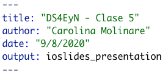

Este encabezado determina los parámetros generales de formato para el reporte a compilar. En lenguaje computacional se entiende como los metadatos del documento; esto es, información que define el formato del archivo resultante, más no su contenido.

Este encabezado se crea automáticamente cuando se selcciona el tipo de documento con el que se desea trabajar y siempre va entre **- - -**.

El output va a depender del tipo de documento que se selccione, el cual puede ser un *html_document*, *word_document*, *pdf_document*, *ioslides_presentation*, entre otros.

## Estructura de Rmarkdown: YAML

- **Título (title)**: Texto entre comillas que servirá de título general al documento.
- **Subtítulo (subtitle)**: Texto entre comillas que servirá de subtítulo para el título general del documento.
- **Autor (author)**: Texto entre comillas para indicar el nombre del o los autores.
- **Fecha (date)**: Campo para indicar la fecha. En el texto, con la expresión `'\today'`, se solicita que imprima la fecha actual según el calendario del sistema operativo.

## Estructura de Rmarkdown: YAML

*ioslides_presentation*

```r
---
title: "Herramientas Profesionales para Data Science - R Markdown"
author: "Carolina Molinare"
date: "7/12/2021"
output:
  ioslides_presentation:
    widescreen: true
    smaller: true
    transition: default
    incremental: true
---
```

## Estructura de Rmarkdown: YAML

*ioslides_presentation*

| **Opciones** | **Descripción** |
| --- | --- |
| *widescreen: true* | Permite mostrar la presentación utilizando un factor de forma más amplio, usando la opción de pantalla panorámica |
| *smaller: true* | Especificar que se utilice texto más pequeño con la opción más pequeña |
| *transition: default* | Permite modificar la velocidad de transición de las diapositivas. Pueden ser `default`, `slower`, `faster` |
| *incremental: true* | Permite que las listas vayan apareciento de forma incremental |

Para revisar más opciones de YAML hacer click [AQUÍ](https://bookdown.org/yihui/rmarkdown/documents.html)

## Estructura de Rmarkdown: YAML

*html_document*

```r
---
title: "Análisis y visualización de datos con Gapminder"
author: "Carolina Molinare"
date: "7/12/2021"
output:
  html_document:
      toc: true
      toc_depth: 3
      highlight: kate
      theme: spacelab
---
```

## Estructura de Rmarkdown: YAML

*html_document*

| **Opciones** | **Descripción** |
| --- | --- |
| *toc: true* | Añadir una tabla de contenidos |
| *toc_depth: 3* | Especificar la profundidad de los encabezados que aplica (1,2 o 3) |
| *highlight: kate* | Especifica el tipo de letra del texto |
| *theme: spacelab* | especifica el tema Bootstrap que se utilizará para la página |

Para revisar más opciones de YAML hacer click [AQUÍ](https://bookdown.org/yihui/rmarkdown/documents.html)

## Estructura de Rmarkdown: Chunks

Chunks o bloques de códigos

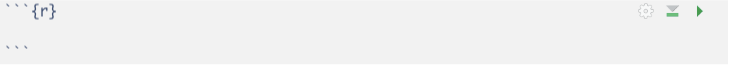

Se puede insertar un chunk de las siguientes formas:

1. Apretando `Ctrl + Alt + I` en Windows y `Cmd + Alt + I` en Mac
2. Seleccionando añadir un chunk de la barra de edición
3. Escribirlo manualmente

## Estructura de Rmarkdown: Chunks

Ejemplo:

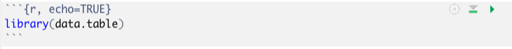

```r
library(data.table)
```

## Estructura de Rmarkdown: Chunks Options

| **Chunk Option** | **Descripción** |
| --- | --- |
| *echo=FALSE* | Previene que se imprima en el output la línea de código asociada a la función que ejecuta |
| *eval=FALSE* | Evita que el código sea evaluado (o se ejecute) |
| *include=FALSE* | Se ejecuta el código, pero sin mostrar los resultados ni el código en el output |
| *message=FALSE* | Previene que se impriman en el output mensajes asociados a la línea de código que ejecuta |
| *warning=FALSE* | Previene que se impriman en el output warnings asociados a la línea de código que ejecuta |
| *error=FALSE* | Se renderiza (o compila) aunque el código devuelva un error |

Revise más opciones [AQUÍ](https://yihui.org/knitr/options/#chunk-options)

## Estructura de Rmarkdown: Texto

Texto mezclado con formato de texto simple (títulos, negritas, entre otros). Lo que esté fuera del YAML y de los chunks es texto que será mostrado en nuestro documento final. Las reglas de formato básicas son las siguientes:

**Títulos y subtítulos**

En el caso de RMarkdown los signos “gato” (#) indican que se está señalando un título o subtítulo de sección. Mientras más signos gatos se pongan se estará indicando que se trata de un título de menor jerarquía.

```r
# Título 1 (nivel de mayor jerarquía)
## Título 2 (nivel de segunda jerarquía)
### Título 3 (nivel de tercera jerarquía)
```

**Énfasis de texto**

Otro elemento importante son los distintas marcas que permiten introducir diferentes énfasis en el texto.

*cursiva*,**negrita**, subindice<sub>2</sub> y supraindice<sup>2</sup>

```r
*cursiva*,**negrita**, subindice~2~ y supraindice^2^
```

## Estructura de Rmarkdown: Texto

**Énfasis de texto**

```r
Así agregamos una nota al pie [^1].
```

Así agregamos una nota al pie <sup>1</sup>.

```r
- Enlaces web: [CIEN-UDP](https://cien.udp.cl)
```

- Enlaces web: [CIEN-UDP](https://cien.udp.cl)

```r
- Imágenes: ![](/Users/caromolinare/Documents/Dipolomado CIEN/logo.png)
```

- Imágenes:

[figure not shown]

## Estructura de Rmarkdown: Texto

**Énfasis de texto**

Otra forma de agregar imágenes para regular el su tamaño es de la siguiente forma:

[figure not shown]

[figure not shown]

## Estructura de Rmarkdown: Texto

**Listas**

Pueden ocuparse números, para listas numeradas o signos asterisco (*) o signos más (+), para definir listas no numeradas

```r
Construcción de una lista numerada

 1. Elemento 1
 2. Elemento 2
```

1. Elemento 1
2. Elemento 2

## Estructura de Rmarkdown: Texto

**Listas**

```r
Lista sin números, con sublista numerada (tabulado es de 4 espacios)

 + Elemento 1
 + Elemento 2
     1. Sub elemento 1.
     2. Sub elemento 2.
```

- Elemento 1
- Elemento 2
  1. Sub elemento 1.
  2. Sub elemento 2.

## Estructura de Rmarkdown: Texto

**Tablas**

La construcción de tablas en RMarkdown se realiza separando los elementos de cada columna con un tabulador vertical (|). Cada fila de texto corresponderá a una fila de la tabla.

Se puede definir la alineación del texto según la distribución de guiones debajo de los títulos. Si los guiones exceden hacia ambos lados del texto, este quedará centrado. Si excede hacia uno u otro lado quedará alineado hacia la izquierda o la derecha.

Las reglas para destacar texto, incluir enlaces y notas al pie, también aplican las tablas. No es necesario separar cada fila con guiones, basta comenzar una nueva fila de texto.

## Estructura de Rmarkdown: Texto

**Tablas**

```r
Table: Tabla simple

 **Título Columna 1** |  **Título columna 2** |
----------------------| ----------------------|
*Texto 1* | Texto 2
*Texto 3* | Texto 4
```

Tabla simple

| **Título Columna 1** | **Título columna 2** |
| --- | --- |
| *Texto 1* | Texto 2 |
| *Texto 3* | Texto 4 |

## Rpubs

Es una plataforma que nos permite publicar nuestros trabajos e informes en Rmarkdown.

Para utilizarlo debemos: